# Predicting Wildfire Occurrence Using Climate Variables

SIMBANEGAVI_SIMBARASHE JEONGWON YOO NITHIN RAVINDRA REEDY

2025-12-08

## 1. Load data

```r
fire_all <- read_csv("Fire_Incidence_Data 2018-2019.csv")
glimpse(fire_all)
```

```
## Rows: 56,025
## Columns: 19
## $ latitude  <dbl> 38.9, 38.9, 38.9, 38.9, 38.9, 38.9, 38.9, 38.9, 38.9, 38.9, …
## $ longitude <dbl> -77.1, -77.1, -77.1, -77.1, -77.1, -77.1, -77.1, -77.1, -77.…
## $ Year      <dbl> 2019, 2019, 2019, 2019, 2019, 2019, 2019, 2019, 2019, 2019, …
## $ Wildfire  <chr> "No", "No", "No", "No", "No", "No", "No", "No", "No", "No", …
## $ pr        <dbl> 9.4, 0.0, 0.4, 0.0, 1.7, 0.0, 0.0, 0.0, 0.0, 0.0, 0.0, 0.0, …
## $ rmax      <dbl> 90.3, 82.9, 89.7, 91.7, 100.0, 100.0, 64.1, 72.6, 77.0, 77.6…
## $ rmin      <dbl> 65.4, 67.9, 77.4, 66.4, 52.0, 51.9, 26.4, 24.6, 29.0, 26.0, …
## $ sph       <dbl> 0.01208, 0.00910, 0.01013, 0.01090, 0.01110, 0.00693, 0.0037…
## $ srad      <dbl> 57.2, 60.4, 108.9, 185.0, 182.3, 153.4, 189.4, 183.9, 183.0,…
## $ tmmn      <dbl> 291, 288, 289, 289, 288, 279, 279, 280, 282, 282, 282, 284, …
## $ tmmx      <dbl> 296, 291, 291, 295, 298, 291, 290, 294, 296, 297, 298, 297, …
## $ vs        <dbl> 2.9, 5.7, 3.5, 2.4, 5.1, 5.3, 2.4, 2.7, 3.2, 3.3, 2.2, 3.3, …
## $ bi        <dbl> 0, 28, 21, 20, 0, 29, 24, 27, 29, 30, 26, 29, 0, 32, 29, 33,…
## $ fm100     <dbl> 19.5, 18.5, 18.6, 18.7, 19.1, 19.1, 16.3, 14.8, 14.1, 13.7, …
## $ fm1000    <dbl> 18.5, 18.6, 18.7, 18.9, 18.8, 18.8, 18.5, 18.0, 17.8, 17.7, …
## $ erc       <dbl> 15, 21, 20, 22, 15, 23, 29, 32, 33, 34, 34, 33, 19, 27, 32, …
## $ etr       <dbl> 2.4, 3.0, 2.1, 2.9, 4.5, 2.9, 3.8, 4.5, 4.8, 5.2, 4.2, 4.3, …
## $ pet       <dbl> 1.7, 2.0, 1.7, 2.4, 3.3, 2.1, 2.6, 3.0, 3.3, 3.5, 2.9, 3.0, …
## $ vpd       <dbl> 0.52, 0.43, 0.28, 0.44, 0.69, 0.35, 0.83, 1.02, 1.03, 1.13, …
```

## 2.Confirm years in the Data

```r
table(fire_all$Year)
```

```
##
##  2018  2019
## 28058 27967
```

## 3.Select Target + Climate Predictors + Location

```r
fire_model <- fire_all %>%
select(
Wildfire,     # TARGET (Yes/No)
Year,
latitude,
longitude,
pr,
rmax,
rmin,
sph,
srad,
tmmn
) %>%
drop_na()

glimpse(fire_model)
```

```
## Rows: 56,025
## Columns: 10
## $ Wildfire  <chr> "No", "No", "No", "No", "No", "No", "No", "No", "No", "No", …
## $ Year      <dbl> 2019, 2019, 2019, 2019, 2019, 2019, 2019, 2019, 2019, 2019, …
## $ latitude  <dbl> 38.9, 38.9, 38.9, 38.9, 38.9, 38.9, 38.9, 38.9, 38.9, 38.9, …
## $ longitude <dbl> -77.1, -77.1, -77.1, -77.1, -77.1, -77.1, -77.1, -77.1, -77.…
## $ pr        <dbl> 9.4, 0.0, 0.4, 0.0, 1.7, 0.0, 0.0, 0.0, 0.0, 0.0, 0.0, 0.0, …
## $ rmax      <dbl> 90.3, 82.9, 89.7, 91.7, 100.0, 100.0, 64.1, 72.6, 77.0, 77.6…
## $ rmin      <dbl> 65.4, 67.9, 77.4, 66.4, 52.0, 51.9, 26.4, 24.6, 29.0, 26.0, …
## $ sph       <dbl> 0.01208, 0.00910, 0.01013, 0.01090, 0.01110, 0.00693, 0.0037…
## $ srad      <dbl> 57.2, 60.4, 108.9, 185.0, 182.3, 153.4, 189.4, 183.9, 183.0,…
## $ tmmn      <dbl> 291, 288, 289, 289, 288, 279, 279, 280, 282, 282, 282, 284, …
```

## 4.Convert Wildfire to a Factor

```r
fire_model <- fire_model %>%
mutate(Wildfire = as.factor(Wildfire))

levels(fire_model$Wildfire)
```

```
## [1] "No"  "Yes"
```

## 5.Temporal Split (2018 = TRAIN, 2019 = TEST)

```r
fire_train <- fire_model %>%
filter(Year == 2018)

fire_test <- fire_model %>%
filter(Year == 2019)

nrow(fire_train)
```

```
## [1] 28058
```

```r
nrow(fire_test)
```

```
## [1] 27967
```

## 6. Preprocessing Recipe (Training Data ONLY)

```r
fire_recipe <- recipe(
  Wildfire ~ .,
  data = fire_train
) %>%
  step_rm(Year) %>%
  step_normalize(all_numeric_predictors()) %>%
  step_upsample(Wildfire)
```

## 7. Define the KNN Classification Model

```r
knn_model <- nearest_neighbor(
neighbors = 5,
weight_func = "rectangular",
dist_power = 2
) %>%
set_engine("kknn") %>%
set_mode("classification")

knn_model
```

```
## K-Nearest Neighbor Model Specification (classification)
##
## Main Arguments:
##   neighbors = 5
##   weight_func = rectangular
##   dist_power = 2
##
## Computational engine: kknn
```

## 8. Create the Workflow

```r
fire_wf <- workflow() %>%
add_recipe(fire_recipe) %>%
add_model(knn_model)

fire_wf
```

```
## ══ Workflow ════════════════════════════════════════════════════════════════════
## Preprocessor: Recipe
## Model: nearest_neighbor()
##
## ── Preprocessor ────────────────────────────────────────────────────────────────
## 3 Recipe Steps
##
## • step_rm()
## • step_normalize()
## • step_upsample()
##
## ── Model ───────────────────────────────────────────────────────────────────────
## K-Nearest Neighbor Model Specification (classification)
##
## Main Arguments:
##   neighbors = 5
##   weight_func = rectangular
##   dist_power = 2
##
## Computational engine: kknn
```

## 9. Train the Model on 2018 Data

```r
knn_fit <- fit(fire_wf, data = fire_train)
```

## 10. Predict Wildfire Occurrence for 2019

```r
fire_predictions <- predict(knn_fit, fire_test) %>%
bind_cols(fire_test)

head(fire_predictions)
```

```
## # A tibble: 6 × 11
##   .pred_class Wildfire  Year latitude longitude    pr  rmax  rmin     sph  srad
##   <fct>       <fct>    <dbl>    <dbl>     <dbl> <dbl> <dbl> <dbl>   <dbl> <dbl>
## 1 Yes         No        2019     38.9     -77.1   9.4  90.3  65.4 0.0121   57.2
## 2 No          No        2019     38.9     -77.1   0    82.9  67.9 0.0091   60.4
## 3 No          No        2019     38.9     -77.1   0.4  89.7  77.4 0.0101  109.
## 4 No          No        2019     38.9     -77.1   0    91.7  66.4 0.0109  185
## 5 No          No        2019     38.9     -77.1   1.7 100    52   0.0111  182.
## 6 No          No        2019     38.9     -77.1   0   100    51.9 0.00693 153.
## # ℹ 1 more variable: tmmn <dbl>
```

## 11. Confusion Matrix (Prediction Performance)

```r
conf_mat(
fire_predictions,
truth = Wildfire,
estimate = .pred_class
)
```

```
##           Truth
## Prediction    No   Yes
##        No  24524   930
##        Yes  2376   137
```

## 12. Classification Metrics (Accuracy, Recall, Precision, F1)

```r
knn_metrics = yardstick::metric_set(
  yardstick::accuracy,
  yardstick::precision,
  yardstick::recall,
  yardstick::f_meas
)

knn_metrics(
  fire_predictions,
  truth = Wildfire,
  estimate = .pred_class,
  event_level = 'second'
)
```

```
## # A tibble: 4 × 3
##   .metric   .estimator .estimate
##   <chr>     <chr>          <dbl>
## 1 accuracy  binary        0.882
## 2 precision binary        0.0545
## 3 recall    binary        0.128
## 4 f_meas    binary        0.0765
```

After specifying wildfire (“Yes”) as the positive class, the KNN model achieved an overall accuracy of 88.2%; however, its performance in detecting wildfire events was limited. The precision was 5.44%, indicating that only a small proportion of predicted wildfire events corresponded to actual wildfires. The recall was 12.84%, meaning that the model detected only about one out of every eight real wildfires. The F1-score of 7.65% further confirms the weak balance between precision and recall for wildfire detection. These results suggest that while the model performs well in identifying non-wildfire conditions, it struggles to reliably detect wildfire occurrences. This limitation is largely attributed to the strong class imbalance and the inherent complexity of wildfire–climate relationships.

## 13. Kappa

```r
metric_set(kap)(
  fire_predictions,
  truth = Wildfire,
  estimate = .pred_class,
  event_level = "second"   # "Yes" (Wildfire) is the positive class
)
```

```
## # A tibble: 1 × 3
##   .metric .estimator .estimate
##   <chr>   <chr>          <dbl>
## 1 kap     binary        0.0243
```

Although the KNN model achieved high accuracy, the very low Kappa value confirms that its predictive power for wildfire occurrence is weak and only marginally better than random guessing.

## 14. ROC-AUC

```r
# Get predicted probabilities for both classes
fire_prob <- predict(knn_fit, fire_test, type = "prob") %>%
  bind_cols(fire_test)

# Check the probability column names
colnames(fire_prob)
```

```
##  [1] ".pred_No"  ".pred_Yes" "Wildfire"  "Year"      "latitude"  "longitude"
##  [7] "pr"        "rmax"      "rmin"      "sph"       "srad"      "tmmn"
```

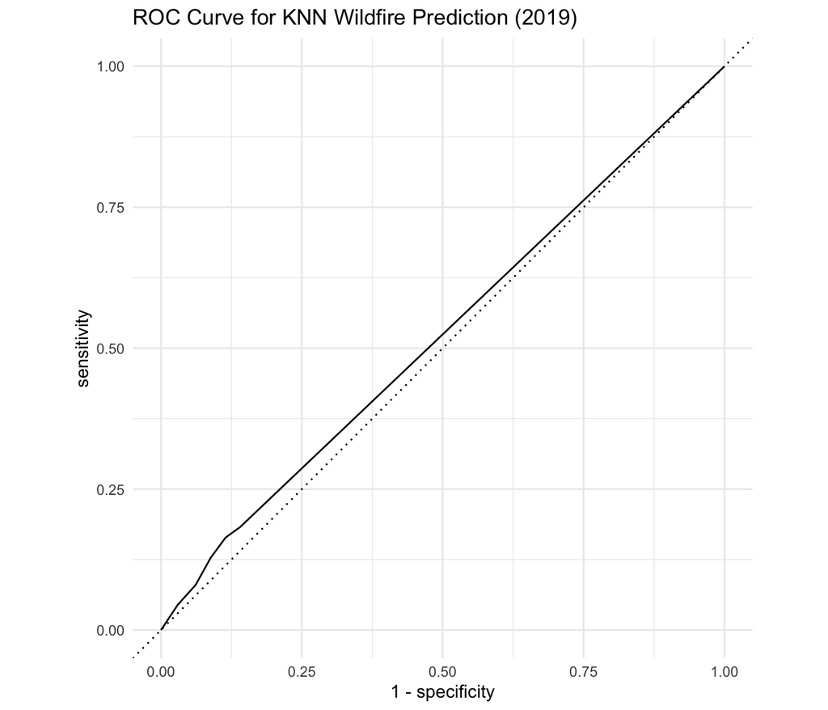

```r
# Create ROC object
roc_obj <- roc_curve(
  fire_prob,
  truth = Wildfire,
  .pred_Yes,
  event_level = "second"
)

# Plot ROC curve using ggplot
autoplot(roc_obj) +
  ggtitle("ROC Curve for KNN Wildfire Prediction (2019)") +
  theme_minimal()
```

# knn + SMOTE

```r
fire_recipe_smote <- recipe(
  Wildfire ~ .,
  data = fire_train
) %>%
  step_rm(Year) %>%
  step_normalize(all_numeric_predictors()) %>%
  step_smote(Wildfire)

fire_recipe_smote

prep_smote <- prep(fire_recipe_smote)
baked_smote <- bake(prep_smote, new_data = NULL)
table(baked_smote$Wildfire)
```

```
##
##    No   Yes
## 26950 26950
```

```r
fire_wf_smote <- workflow() %>%
  add_recipe(fire_recipe_smote) %>%
  add_model(knn_model)

fire_wf_smote
```

```
## ══ Workflow ════════════════════════════════════════════════════════════════════
## Preprocessor: Recipe
## Model: nearest_neighbor()
##
## ── Preprocessor ────────────────────────────────────────────────────────────────
## 3 Recipe Steps
##
## • step_rm()
## • step_normalize()
## • step_smote()
##
## ── Model ───────────────────────────────────────────────────────────────────────
## K-Nearest Neighbor Model Specification (classification)
##
## Main Arguments:
##   neighbors = 5
##   weight_func = rectangular
##   dist_power = 2
##
## Computational engine: kknn
```

```r
knn_fit_smote <- fit(fire_wf_smote, data = fire_train)

fire_predictions_smote <- predict(knn_fit_smote, fire_test) %>%
  bind_cols(fire_test)

head(fire_predictions_smote)
```

```
## # A tibble: 6 × 11
##   .pred_class Wildfire  Year latitude longitude    pr  rmax  rmin     sph  srad
##   <fct>       <fct>    <dbl>    <dbl>     <dbl> <dbl> <dbl> <dbl>   <dbl> <dbl>
## 1 Yes         No        2019     38.9     -77.1   9.4  90.3  65.4 0.0121   57.2
## 2 No          No        2019     38.9     -77.1   0    82.9  67.9 0.0091   60.4
## 3 No          No        2019     38.9     -77.1   0.4  89.7  77.4 0.0101  109.
## 4 No          No        2019     38.9     -77.1   0    91.7  66.4 0.0109  185
## 5 Yes         No        2019     38.9     -77.1   1.7 100    52   0.0111  182.
## 6 No          No        2019     38.9     -77.1   0   100    51.9 0.00693 153.
## # ℹ 1 more variable: tmmn <dbl>
```

```r
conf_mat(
  fire_predictions_smote,
  truth   = Wildfire,
  estimate = .pred_class
)
```

```
##           Truth
## Prediction    No   Yes
##        No  22807   860
##        Yes  4093   207
```

```r
knn_metrics(
  fire_predictions_smote,
  truth    = Wildfire,
  estimate = .pred_class,
  event_level = "second"
)
```

```
## # A tibble: 4 × 3
##   .metric   .estimator .estimate
##   <chr>     <chr>          <dbl>
## 1 accuracy  binary        0.823
## 2 precision binary        0.0481
## 3 recall    binary        0.194
## 4 f_meas    binary        0.0771
```

```r
fire_prob_smote <- predict(knn_fit_smote, fire_test, type = "prob") %>%
  bind_cols(fire_test)

colnames(fire_prob_smote)
```

```
##  [1] ".pred_No"  ".pred_Yes" "Wildfire"  "Year"      "latitude"  "longitude"
##  [7] "pr"        "rmax"      "rmin"      "sph"       "srad"      "tmmn"
```

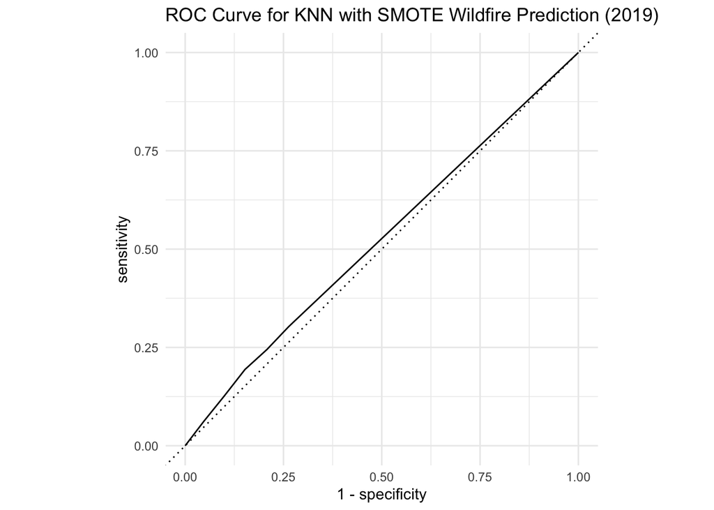

```r
roc_obj_smote <- roc_curve(
  fire_prob_smote,
  truth = Wildfire,
  .pred_Yes,
  event_level = "second"
)

autoplot(roc_obj_smote) +
  ggtitle("ROC Curve for KNN with SMOTE Wildfire Prediction (2019)") +
  theme_minimal()
```